# Taller de Git

David Mateos - Agresta S. Coop.

29 de noviembre de 2022

# Presentación

## Qué es Git?

- Es un **sistema de control de versiones** distribuido.
- Es un programa de línea de comandos.

## Para qué nos sirve?

## Para qué nos sirve?

- Seguimiento de cambios.
- Olvidarnos del “mándame la última versión”.
- Mantener cómodamente distintas versiones de un proyecto.
- Aprender la lógica de colaboración en proyectos de SL.

## Para quién?

- En programación
- Diseño web
- En general, para archivos de texto plano:
  - Documentación,
  - textos auń sin maquetar,
  - Markdown/RstText/etc.

# Qué vamos a ver?

## Programa

1. Trabajo en solitario: en local.
2. Trabajo en solitario: con repos remotos.
3. Trabajar en equipo: con repos remotos.

# Qué es lo que hace git?

## Un repositorio (“repo”) es un directorio

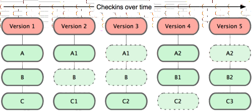

## Snapshots de los archivos del directorio

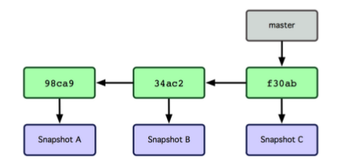

# Primeros pasos

## Git Bash

En Windows hay varios tipos de shell, lo ideal será usar `Git Bash` que se habrá instalado con Git y tiene esta pinta:

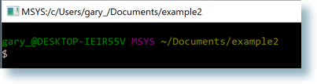

## Git Gui

- Git viene con dos herramientas GUI:
  - Para hacer commits (git-gui).
  - Para navegar (gitk).
- Otras herramientas [GUI](http://git-scm.com/downloads/guis).

## Nos presentamos

```bash
git config --global user.name 'David Mateos'
git config --global user.email 'dmateos@agresta.org'
git config --global --list
```

## Comandos básicos de terminal

- `pwd`: muestra en qué directorio estamos.
- `cd directorio`: cambia de directorio.
- `cd ..`: sube un directorio.
- `ls`: lista el contenido del directorio actual.

`TAB` para autocompletar.

## Creamos nuestro primer repo

```bash
cd carpeta_destino
git init
```

## Qué hay de nuevo?

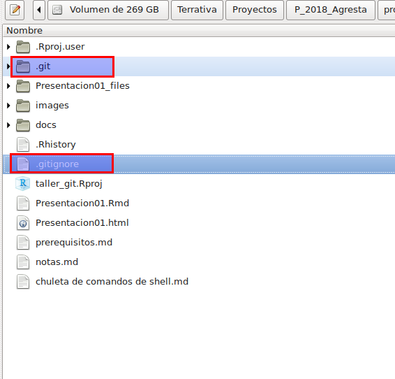

## Qué hay de nuevo?

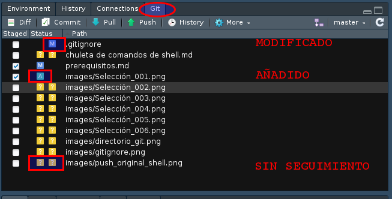

# El flujo de trabajo en Git

## Vista general

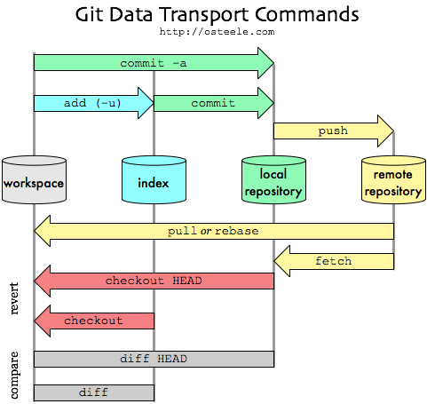

## Empezamos a hacer seguimiento de nuestros archivos

```bash
$ git commit -a -m "commit inicial"
```

## Cambiamos cosas en el proyecto

- Añadir/borrar lineas de archivos de texto.
- Añadir archivos.
- Borrar archivos
- …

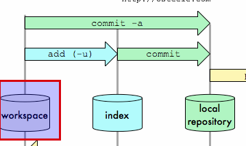

## Añadir al índice

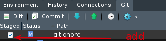

```bash
$ git add nombre_archivo  # ó
$ git add .
```

## Cómo estamos?

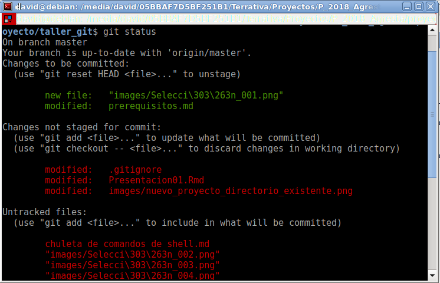

```bash
$ git status
```

## Cómo estamos?

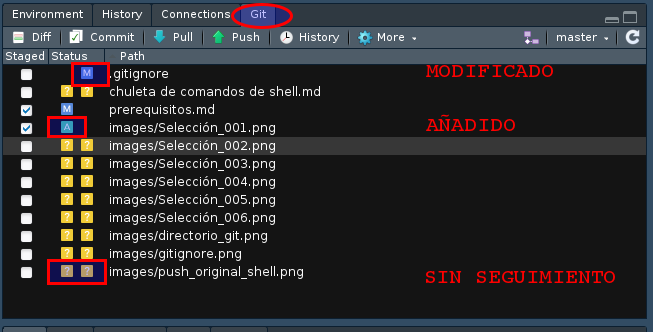

```bash
$ git status
```

## “Hacer” commit

[figure not shown]

```bash
$ git commit -m "texto del commit"
```

## Cómo estamos?

```bash
$ git status
```

Seguimos haciendo cambios:

1. Cambios en los archivos
2. Stage
3. Commit

## Ver el historial de cambios

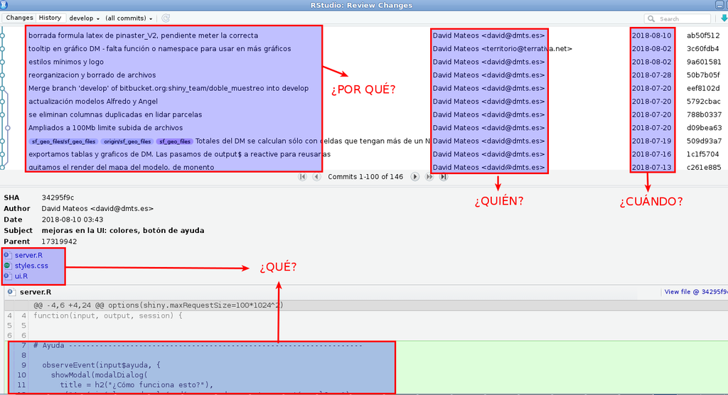

## gitignore

Si hay archivos de los que no queremos hacer seguimiento.

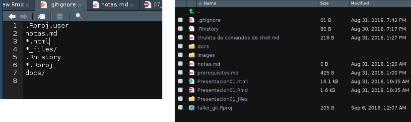

# Ramas

## Ramas

- Las ramas se crean en local.
- Permiten tener distintas versiones del código.
- Se suelen usar varias ramas:
  - `main`. Siempre, por defecto.
  - `develop`.
  - `feature_x`. Ramas por *features*.

## Rama main

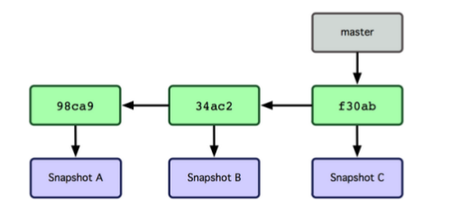

## checkout

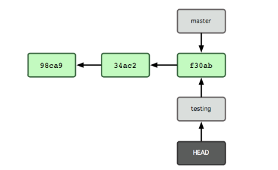

```bash
git branch nombre_rama # crea una rama
git checkout nombre_rama # se cambia a una rama
git checkout -b # crea una rama y se cambia a ella
```

## Commits en la rama

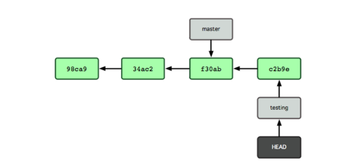

## Cambios entre ramas

```bash
git checkout rama
```

## Movernos entre ‘snapshots’

```bash
git checkout SHA
git checkout nombre_rama
```

## Mezcla de ramas

Estando en la rama de destino:

```bash
git merge rama_a_unir
```

# Buenas prácticas

## Buenas prácticas - Git

- Hacer commits frecuentemente.
- No mezclar en el mismo commit cambios que no tengan que ver entre sí.
- Poner buenos mensajes de commit.

# Repos remotos

## Distintos proveedores de servicios

- [Github](https://github.com/).
- [Bitbucket](https://bitbucket.org/).
- [Gitlab](https://about.gitlab.com/).
- [Gitea](https://gitea.io/en-us/).

## Github

- Crear una cuenta con el plan gratuito.
- Elegir un buen nombre ;-).
- Crear un token (settings>Developers>Tokens).

## Subir un proyecto local

1. Crear el nuevo repo en la app web (https://github.com/).

[figure not shown]

## Subir un proyecto local

1. Crear el nuevo repo en la app web (https://github.com/).

[figure not shown]

## Subir un proyecto local

(Seguir las instrucciones)

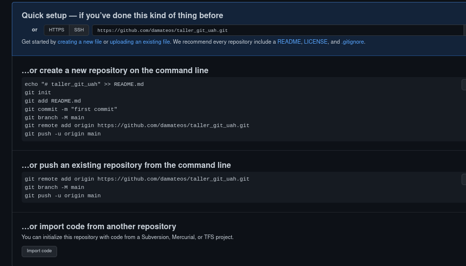

## Subir un proyecto local

Si ya tenemos un proyecto empezado

```bash
git remote add origin http://github.com/usuario/nombre_repo.git
git push -u origin main
```

En general:

```bash
git remote add nombre_remoto url_repo_remoto
git push -u nombre_remoto rama_remota
```

## Descagar (clonar) repo remoto

Si aún no hemos empezado el proyecto en local.

```
git clone https://github.com/usuario/repositorio.git
```

## Comprobar enlace remoto-local

Comprobarlo con:  
`git remote -v`

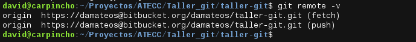

# Flujos de trabajo típicos

## Una persona proyecto simple

commit - commit - commit - (push) - commit - …

## Una persona, ramas

- Cambios o pruebas que puede que no se queden
- Proyecto con versión en funcionamiento y versión desarrollo.
- Uso con metodologías ágiles.
- Alguien tiene que revisar el código antes de integrarlo (grupos).

## Una persona, ramas

- Rama main y rama develop.
- Ramas por *features*.

## Fork

- Copias el proyecto de otro/a.
- Copias un proyecto tuyo ya terminado.

## Fork - Aportar a un proyecto de otros/as

- Como suelen funcionar los proyectos SL.
- Fork del proyecto - clone en local.
- Cambios (commit - commmit - push).
- Pull Request a dueños/as proyecto original.

## Proyecto de grupo sin ramas

- Dar permisos en github.
- Clonar repositorio, trabajar de forma normal (organizarse!!) commit - commit - commit -
- Antes de subir los cambios hay que bajarlos (pull)
- puede haber conflictos, los solucionamos en local
- subimos los cambios ya sin conflicto (push)

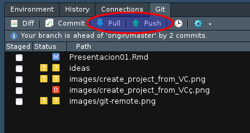

```bash
git push origin main #Envia los cambios al repo remoto
git pull #Trae cambios del repo remoto
```

## Proyecto de grupo con ramas

- Dar permisos en github.
- Ramas por *feature*, en local.
- Puede haber rama `develop` o no.
- Si hay `develop` –> encargado de hacer merge a master.

# Qué puede pasar al juntar dos ramas?

## “fast foward”

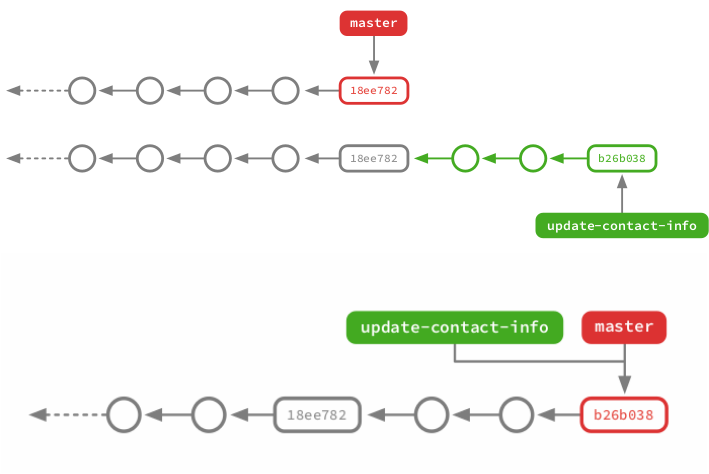

## Merge con commit

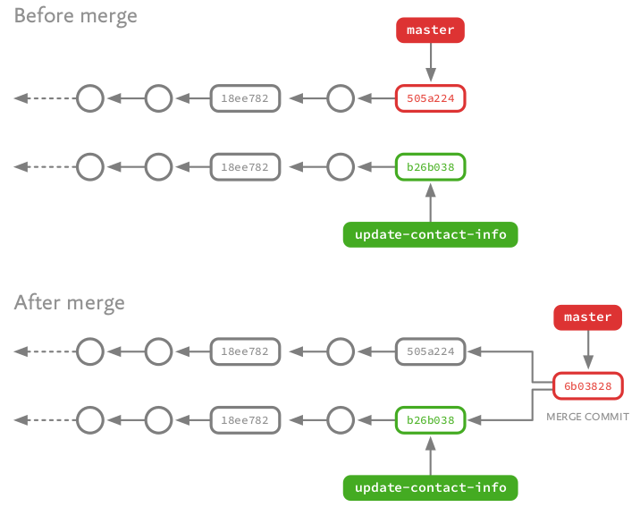

## Conflicto

También puede pasar con una sóla rama

[figure not shown]

# Explorando github

## Visión general

- **Perfil**. Nuestro listado de repositorios. Podemos elegir los principales a mostrar.
- **Settings**. No es necesario hacer nada, pero resulta útil por lo menos añadir el nombre, una imagen. Crear token para acceso desde terminal.

# Herramientas gestión de proyecto

## Permisos

- Quién puede hacer cambios a nuestro repo

## Issues

- Etiquetas
- Asignar responsabilidades
- Tiempo dedicación

## Releases

- Son como tags
- archivo descarga

# Referencias

- [Documentación ofiical](https://git-scm.com/docs).
- Libro [Pro git](https://git-scm.com/book/en/v2)